# R Notebook

# Homework week 11 - day 3 - Clustering

This homework involves the mall_customers.csv data we’ve provided, based on data collected in a shopping mall. It will give you an opportunity to practice your new clustering skills.

```r
library(tidyverse)
```

# Question 1

Data exploration

```r
skimr::skim(customers)
```

```
── Data Summary ────────────────────────
                           Values
Name                       customers
Number of rows             200
Number of columns          5
_______________________
Column type frequency:
  character                1
  numeric                  4
________________________
Group variables            None
```

|  | skim_variable | n_missing | complete_rate | min | max | empty | n_unique | whitespace |
| --- | --- | --- | --- | --- | --- | --- | --- | --- |
| 1 | Gender | 0 | 1 | 4 | 6 | 0 | 2 | 0 |

|  | skim_variable | n_missing | complete_rate | mean | sd | p0 | p25 | p50 | p75 | p100 | hist |
| --- | --- | --- | --- | --- | --- | --- | --- | --- | --- | --- | --- |
| 1 | CustomerID | 0 | 1 | 100.50 | 57.87918 | 1 | 50.75 | 100.5 | 150.25 | 200 | ▇▇▇▇▇ |
| 2 | Age | 0 | 1 | 38.85 | 13.96901 | 18 | 28.75 | 36.0 | 49.00 | 70 | ▆▇▅▃▂ |
| 3 | Annual Income (k$) | 0 | 1 | 60.56 | 26.26472 | 15 | 41.50 | 61.5 | 78.00 | 137 | ▆▇▇▂▁ |
| 4 | Spending Score (1-100) | 0 | 1 | 50.20 | 25.82352 | 1 | 34.75 | 50.0 | 73.00 | 99 | ▃▃▇▃▃ |

We have 200 observations, with 5 columns: customerID, gender, age, annual income (in k$) and spending score (running from 1-100)

So each row represents one customer. Spending score potentially is a score for how much money is spend in the mall

We have no missing datapoints, distributions look ok for the type of data it contains (always positive, so slighlty right skewed)

# Question 2

We are interested in creating a marketing campaign to target customers based on their spending score and annual income. Select an appropriate value for k and perform k-means clustering to find if there are meaningful clusters in the data to target the customers.

```r
library(janitor)
library(fastDummies)
library(broom)
library(tidyverse)
library(factoextra)
```

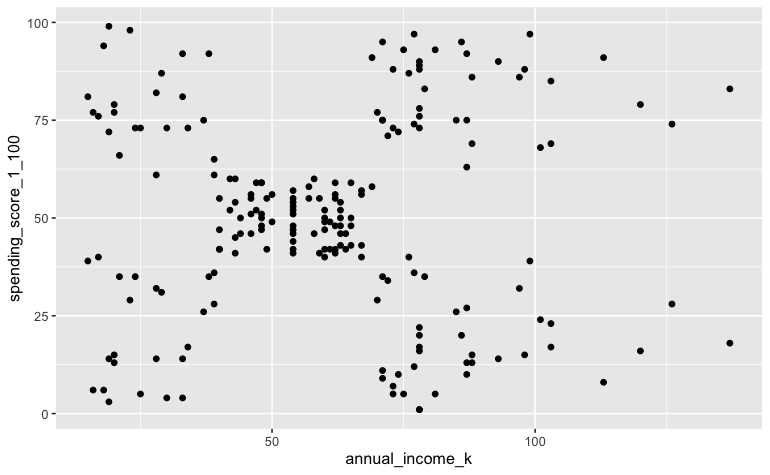

| score_income | value |
| --- | --- |
| annual_income_k | -1.734646247 |
| spending_score_1_100 | -0.433713114 |
| annual_income_k | -1.734646247 |
| spending_score_1_100 | 1.192711064 |
| annual_income_k | -1.696572361 |
| spending_score_1_100 | -1.711617825 |
| annual_income_k | -1.696572361 |
| spending_score_1_100 | 1.037813523 |
| annual_income_k | -1.658498475 |
| spending_score_1_100 | -0.394988729 |

[output cut: 390 more lines]

check each of the methods of choosing k:

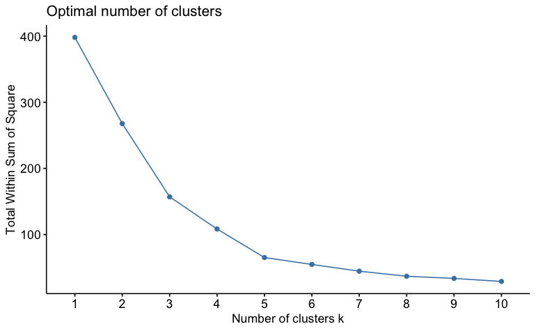

I suggest that the elbow starts at 5

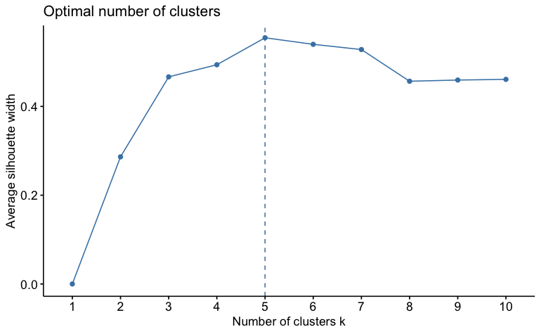

- 5 seems to be ideal here again..

```
Clustering k = 1,2,..., K.max (= 10): .. done
Bootstrapping, b = 1,2,..., B (= 100)  [one "." per sample]:
.................................................. 50
.................................................. 100
```

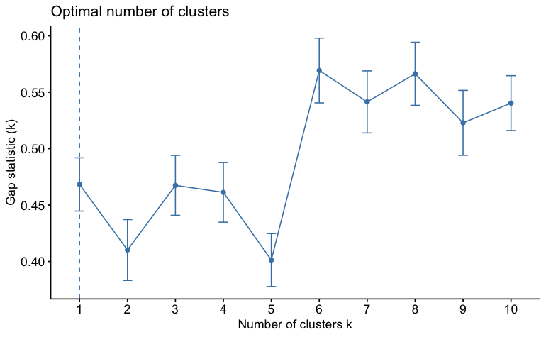

```r
fviz_nbclust(customers_scale, kmeans, method = "gap_stat")
```

Given the results above, I go for 5 clusters

```r
clustered_customers
```

```
K-means clustering with 5 clusters of sizes 22, 81, 23, 39, 35

Cluster means:
  annual_income_k spending_score_1_100
1      -1.3262173           1.12934389
2      -0.2004097          -0.02638995
3      -1.3042458          -1.13411939
4       0.9891010           1.23640011
5       1.0523622          -1.28122394

Clustering vector:
  [1] 3 1 3 1 3 1 3 1 3 1 3 1 3 1 3 1 3 1 3 1 3 1 3 1 3 1 3 1 3 1 3 1 3 1 3 1 3 1 3 1 3 1 3 2 3 1 2 2 2 2 2 2 2 2 2 2 2 2 2 2 2 2 2 2 2 2 2 2 2 2 2 2 2 2 2 2 2 2 2 2
 [81] 2 2 2 2 2 2 2 2 2 2 2 2 2 2 2 2 2 2 2 2 2 2 2 2 2 2 2 2 2 2 2 2 2 2 2 2 2 2 2 2 2 2 2 4 5 4 2 4 5 4 5 4 2 4 5 4 5 4 5 4 5 4 2 4 5 4 5 4 5 4 5 4 5 4 5 4 5 4 5 4
[161] 5 4 5 4 5 4 5 4 5 4 5 4 5 4 5 4 5 4 5 4 5 4 5 4 5 4 5 4 5 4 5 4 5 4 5 4 5 4 5 4

Within cluster sum of squares by cluster:
[1]  5.217630 14.485632  7.577407 19.655252 18.304646
 (between_SS / total_SS =  83.6 %)

Available components:

[1] "cluster"      "centers"      "totss"        "withinss"     "tot.withinss" "betweenss"    "size"         "iter"         "ifault"
```

```r
#some more info on clusters
tidy(clustered_customers, col.names = colnames(customers))
```

```
Error in names(x) <- value :
  'names' attribute [5] must be the same length as the vector [2]
```

| customer_id | gender | age | annual_income_k | spending_score_1_100 | cluster |
| --- | --- | --- | --- | --- | --- |
| 1 | Male | 19 | 15 | 39 | 3 |
| 2 | Male | 21 | 15 | 81 | 1 |
| 3 | Female | 20 | 16 | 6 | 3 |
| 4 | Female | 23 | 16 | 77 | 1 |
| 5 | Female | 31 | 17 | 40 | 3 |
| 6 | Female | 22 | 17 | 76 | 1 |
| 7 | Female | 35 | 18 | 6 | 3 |
| 8 | Female | 23 | 18 | 94 | 1 |
| 9 | Male | 64 | 19 | 3 | 3 |
| 10 | Female | 30 | 19 | 72 | 1 |

[output cut: 190 more lines]

| cluster | age | annual_income_k | spending_score_1_100 |
| --- | --- | --- | --- |
| 1 | 25.27273 | 25.72727 | 79.36364 |
| 2 | 42.71605 | 55.29630 | 49.51852 |
| 3 | 45.21739 | 26.30435 | 20.91304 |
| 4 | 32.69231 | 86.53846 | 82.12821 |
| 5 | 41.11429 | 88.20000 | 17.11429 |

# Question 3

Visualise the clustering for your chosen value of k.

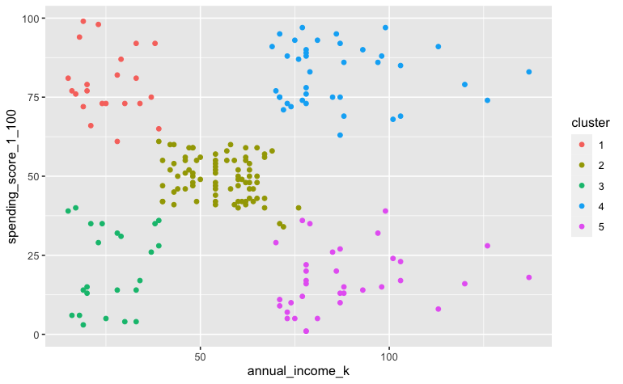

Based on this graph, we see 5 groups of customers: Within group of customers that have a high annual income (mean income 86 and 88), there is a group with a high spending score, and a group with low spending score.

This same pattern is visible for customers with a low annual income (mean 25 and 26k)

Only customers with an average income (55k), sahre a similar spending score with a mean of 49

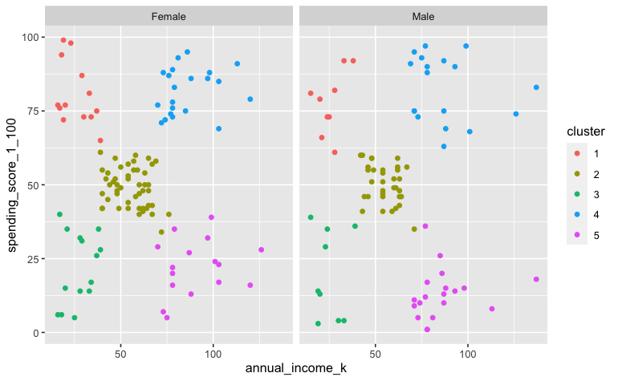

The different genders give the same clustering pattern.

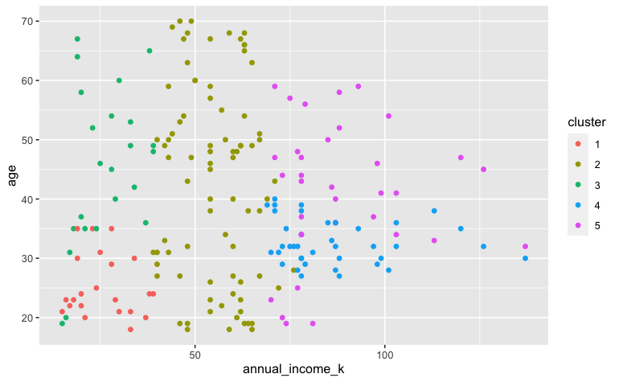

# Question 4

Do you think the clustering seems a good fit for this data?

# Question 5

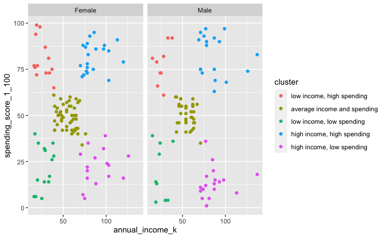